# Analysis of the overlap between significant variants associated with thermal adaptation in a worldwide collection of *Zymoseptoria tritici* and previously identified QTL’s for thermal adaptation, and 

### 2.0.4 Lendenmann QTL –> GWAS 22ºC WWC

```r
lendenmannannotfromalice<-read.csv("QTLfromAlicepaper_SMP_02022024.csv", header=TRUE, sep= ",")  %>% rename(chromosome=QTL_CHR, Phenotype2=Phenotype)


alicegea<-read_csv("alicegeagenes.csv")

totalsub5<-read_tsv("Significant_GEMMA_22C_temperatureswithphen_fdr0.1_v1.tsv", col_names = c("chromosome", "BP", "Phenotype"))

chromis5<-unique(totalsub5$chromosome)
phenops5<-unique(totalsub5$Phenotype)


for (chrm in chromis5){
  for (ph in phenops5){
    signiftem5=totalsub5 %>% filter(chromosome == chrm) %>% filter(Phenotype == ph) %>% group_by(chromosome, Phenotype)
    lendatemp=lendenmannannotfromalice %>% filter(chromosome == chrm)
    tempi35=left_join(signiftem5, lendatemp) %>% mutate(lendafound= ifelse(QTL_start <= BP & QTL_end >= BP, "yes", "no:("))
    tempi35$lendafound<-as.character(tempi35$lendafound)
    if (exists("tempi45_22c") == FALSE) {
            tempi45_22c=tempi35
          } else {
            tempi45_22c=full_join(tempi45_22c, tempi35)
          }
  }
}

tempi45_22c %>% filter(lendafound == "yes")

#write_csv(tempi45_22c %>% filter(lendafound == "yes"), "GWAS22C_WWC_lendenmannannotfromalice_notpeak_notbygenes_v2.csv")


for (chrm in chromis5){
  for (ph in phenops5){
    signiftem5=totalsub5 %>% filter(chromosome == chrm) %>% filter(Phenotype == ph) %>% group_by(chromosome, Phenotype)
    geatemp=alicegea %>% filter(chromosome == chrm)
    tempige=left_join(signiftem5, geatemp) %>% mutate(geafound= ifelse(start-2800 <= BP & end+2800 >= BP, "yes", "no:("))
    tempige$geafound<-as.character(tempige$geafound)
    if (exists("tempigea_22c") == FALSE) {
            tempigea_22c=tempige
          } else {
            tempigea_22c=full_join(tempigea_22c, tempige)
          }
  }
}

tempigea_22c %>% filter(geafound == "yes")


#write_csv(tempigea_22c %>% filter(geafound == "yes"), "GWAS22C_WWC_GEAannotfromalice_bygenes_v1.csv")
```

[output not shown]

### 2.0.5 Lendenmann QTL –> GWAS 25ºC WWC

```r
lendenmannannotfromalice<-read.csv("QTLfromAlicepaper_SMP_02022024.csv", header=TRUE, sep= ",")  %>% rename(chromosome=QTL_CHR, Phenotype2=Phenotype)



alicegea<-read_csv("alicegeagenes.csv")

totalsub5<-read_tsv("Significant_GEMMA_25C_temperatureswithphen_fdr0.1_v1.tsv", col_names = c("chromosome", "BP", "Phenotype"))

chromis5<-unique(totalsub5$chromosome)
phenops5<-unique(totalsub5$Phenotype)


for (chrm in chromis5){
  for (ph in phenops5){
    signiftem5=totalsub5 %>% filter(chromosome == chrm) %>% filter(Phenotype == ph) %>% group_by(chromosome, Phenotype)
    lendatemp=lendenmannannotfromalice %>% filter(chromosome == chrm)
    tempi35=left_join(signiftem5, lendatemp) %>% mutate(lendafound= ifelse(QTL_start <= BP & QTL_end >= BP, "yes", "no:("))
    tempi35$lendafound<-as.character(tempi35$lendafound)
    if (exists("tempi45_25c") == FALSE) {
            tempi45_25c=tempi35
          } else {
            tempi45_25c=full_join(tempi45_25c, tempi35)
          }
  }
}

tempi45_25c %>% filter(lendafound == "yes")
```

```
## # A tibble: 0 × 9
## # Groups:   chromosome, Phenotype [0]
## # ℹ 9 variables: chromosome <dbl>, BP <dbl>, Phenotype <chr>, QTL_start <int>,
## #   QTL_end <int>, QTL_peak <int>, Phenotype2 <chr>, Size_interval <chr>,
## #   lendafound <chr>
```

```r
#write_csv(tempi45_25c %>% filter(lendafound == "yes"), "GWAS25C_WWC_lendenmannannotfromalice_notpeak_notbygenes_v2.csv")



for (chrm in chromis5){
  for (ph in phenops5){
    signiftem5=totalsub5 %>% filter(chromosome == chrm) %>% filter(Phenotype == ph) %>% group_by(chromosome, Phenotype)
    geatemp=alicegea %>% filter(chromosome == chrm)
    tempige=left_join(signiftem5, geatemp) %>% mutate(geafound= ifelse(start-2800 <= BP & end+2800 >= BP, "yes", "no:("))
    tempige$geafound<-as.character(tempige$geafound)
    if (exists("tempigea_25c") == FALSE) {
            tempigea_25c=tempige
          } else {
            tempigea_25c=full_join(tempigea_25c, tempige)
          }
  }
}

tempigea_25c %>% filter(geafound == "yes") %>% mutate(new_start=start-2800, new_end=end+2800)
```

```
## # A tibble: 9 × 12
## # Groups:   chromosome, Phenotype [2]
##   chromosome      BP Phenotype     target      gene  Feurtey_genes  start    end
##        <dbl>   <dbl> <chr>         <chr>       <chr> <chr>          <dbl>  <dbl>
## 1          7 1509601 asymptote_25C ZtIPO323_0… ZtIP… Zt09_chr_7.4… 1.51e6 1.51e6
## 2          7 1509601 asymptote_25C ZtIPO323_0… ZtIP… Zt09_chr_7.4… 1.51e6 1.51e6
## 3          7 1509601 asymptote_25C ZtIPO323_0… ZtIP… Zt09_chr_7.4… 1.51e6 1.51e6
## 4          7 1511537 asymptote_25C ZtIPO323_0… ZtIP… Zt09_chr_7.4… 1.51e6 1.51e6
## 5          7 1511537 asymptote_25C ZtIPO323_0… ZtIP… Zt09_chr_7.4… 1.51e6 1.51e6
## 6          7 1512102 asymptote_25C ZtIPO323_0… ZtIP… Zt09_chr_7.4… 1.51e6 1.51e6
## 7          7 1512102 asymptote_25C ZtIPO323_0… ZtIP… Zt09_chr_7.4… 1.51e6 1.51e6
## 8          7 1210613 q25total_25C  ZtIPO323_0… ZtIP… Zt09_chr_7.3… 1.21e6 1.21e6
## 9          7 1210613 q25total_25C  ZtIPO323_0… ZtIP… Zt09_chr_7.3… 1.21e6 1.21e6
## # ℹ 4 more variables: `Seq Description` <chr>, geafound <chr>, new_start <dbl>,
## #   new_end <dbl>
```

```r
#write_csv(tempigea_25c %>% ungroup() %>% filter(geafound == "yes") %>% mutate(new_start=start-2800, new_end=end+2800), "GWAS25C_WWC_GEAannotfromalice_bygenes_v1.csv")
```

# 3 Circular plots of significant variables associated with the growth variables at the 5 temperature conditions

```r
pheno_table<-read_csv("all_varfin_temp.csv") %>% rename(Condition=cond, Phenotype=coliname)

#significant file here is loci


chromosomes_lengths<-read_csv("chromosomelengths.csv")

signif12c<-read_tsv("Significant_GEMMA_12C_temperatureswithphen_fdr0.1_v1.tsv", col_names = c("CHR", "BP", "Phenotype"))
signif15c<-read_tsv("Significant_GEMMA_15C_temperatureswithphen_fdr0.1_v1.tsv", col_names = c("CHR", "BP", "Phenotype"))
signif18c<-read_tsv("Significant_GEMMA_18C_temperatureswithphen_fdr0.1_v1.tsv", col_names = c("CHR", "BP", "Phenotype"))
signif22c<-read_tsv("Significant_GEMMA_22C_temperatureswithphen_fdr0.1_v1.tsv", col_names = c("CHR", "BP", "Phenotype"))
signif25c<-read_tsv("Significant_GEMMA_25C_temperatureswithphen_fdr0.1_v1.tsv", col_names = c("CHR", "BP", "Phenotype"))

significant<-full_join(signif12c, signif15c) %>% full_join(signif18c) %>% full_join(signif22c) %>% full_join(signif25c)

significantdistinct<-distinct(significant) %>% left_join(pheno_table)
significantdistinctmergedgenotypes<-distinct(significantdistinct %>% dplyr::select(-Phenotype, -var, -Type, -Condition))

write_tsv(significantdistinctmergedgenotypes, "significantdistinctmergedgenotypes.tsv", col_names = FALSE)

significantdistinctmergedcondition<-distinct(significantdistinct %>% dplyr::select(-Phenotype, -var, -Type))  %>% ungroup() %>% group_by (Condition) %>% count() %>% ungroup() %>% mutate(percent = n/194)

totalsub12C<-read_csv("totalsub_genes_GWAS_12C_v1.csv")
totalsub15C<-read_csv("totalsub_genes_GWAS_15C_v1.csv")
totalsub18C<-read_csv("totalsub_genes_GWAS_18C_v1.csv")
totalsub22C<-read_csv("totalsub_genes_GWAS_22C_v1.csv")
totalsub25C<-read_csv("totalsub_genes_GWAS_25C_v1.csv")

totalsub_GWAS_WWC<-totalsub12C %>% full_join(totalsub15C) %>% full_join(totalsub18C) %>% full_join(totalsub22C) %>% full_join(totalsub25C) %>% rename(Gene=gene)

totalnumbgenes<-unique(totalsub_GWAS_WWC$Gene)

totalnumbgenes1<-distinct(totalsub_GWAS_WWC %>% left_join(pheno_table) %>% dplyr::select( Gene, chromosome, start, end, Seq_Description)) %>%
  drop_na(Seq_Description) %>% # remove NA values
  filter(!grepl('unnamed_protein_product', Seq_Description)) %>% # remove unnamed pred. genes
  filter(!grepl('uncharacterized_protein', Seq_Description)) %>% # remove unnamed pred. genes
  filter(!grepl('_predicted_protein', Seq_Description)) %>%
  filter(!grepl('SPQ18253.1_2af7a199-4405-43fb-abde-30e69e36a884', Seq_Description)) %>%
  filter(!grepl('hypothetical', Seq_Description))


#92
#154

annotall<-read_csv("annotationsgenefromnewgff3.csv") %>% rename(Gene=gene)

snpeffresultsnew080424<-read_csv("highesteffectlittle.csv", col_names = FALSE)
names(snpeffresultsnew080424) <- c("variant", "Variant_type", "Effect_strength", "Gene", "CHR", "BP")

snpeffresultsnew080424_1<- snpeffresultsnew080424 %>% left_join(annotall) %>% left_join(significant) %>% left_join(pheno_table)
write_csv(snpeffresultsnew080424_1, "forpubsnpeffresults.csv")



highest_positions = significantdistinct %>%
  group_by(CHR,  Phenotype) %>%
  dplyr::select(CHROM = CHR, POS = BP, Phenotype) %>%
  inner_join(., read_tsv(paste0("onlysignificantmafmiss.recode.temperaturesbcftoolsann.ann.tab"), na = ".", col_types = cols(`[1]CHROM`= col_number(), `[2]POS`= col_number())) %>% rename(CHROM=`[1]CHROM`,POS=`[2]POS`, REF=`[3]REF`, ALT=`[4]ALT` , ANN=`[5]ANN`)) %>% dplyr::select(-ANN)%>%
  pivot_longer(-c(CHROM, POS, REF, ALT, Phenotype),
                 names_to = "ID_file", values_to = "Allele")%>%
  filter(!is.na(Allele)) %>% mutate(Allele = as.numeric(Allele)) %>%
  group_by(CHROM, POS, REF, ALT, Phenotype) %>%
  dplyr::mutate(Nb_ref = sum(Allele == 0),
                Nb_non_miss = n(),
                Freq_ref = Nb_ref/Nb_non_miss)


snpalleleinforefalt<-highest_positions %>% filter(CHROM == 2) %>% filter(POS ==
216652)


write_csv(snpalleleinforefalt, "snpalleleinforefalt_chr2_unknown_12C.csv")

temp = full_join(pheno_table, significant) %>%
    dplyr::select(Condition, CHR, BP) %>%
    distinct() %>%
    arrange(CHR, BP) %>%
    inner_join(., chromosomes_lengths) %>%
    mutate(BPcum = BP + Cumu_start) %>%
    filter(CHR < 14) %>%
  mutate(height = 1) %>%
  dplyr::select(Condition, CHR, BP, height)



short_chr = filter(chromosomes_lengths, CHR < 14) %>%
  mutate(x0 = 0) %>%
  dplyr::select(CHR, x0, Length) %>%
  add_row(CHR = 0, x0 = 0, Length = 2800000)


short_chr$color = c(rep("grey20",13), "white")


#add lendenmann qtls where it matches:


lend22c<-read_csv("GWAS22C_WWC_lendenmannannotfromalice_notpeak_notbygenes_v2.csv")  %>% rename(CHR=chromosome) %>% left_join(snpeffresultsnew080424_1)
lend12c<-read_csv("GWAS12C_WWC_lendenmannannotfromalice_notpeak_notbygenes_v2.csv") %>% rename(CHR=chromosome) %>% left_join(snpeffresultsnew080424_1)



lend25c<-read_csv("GWAS25C_WWC_lendenmannannotfromalice_notpeak_notbygenes_v2.csv") %>% dplyr::select(chromosome, QTL_start, QTL_end) %>% rename(CHR=chromosome)
lend22c<-read_csv("GWAS22C_WWC_lendenmannannotfromalice_notpeak_notbygenes_v2.csv") %>% dplyr::select(chromosome, QTL_start, QTL_end) %>% rename(CHR=chromosome)
lend18c<-read_csv("GWAS18C_WWC_lendenmannannotfromalice_notpeak_notbygenes_v2.csv") %>% dplyr::select(chromosome, QTL_start, QTL_end) %>% rename(CHR=chromosome)
lend15c<-read_csv("GWAS15C_WWC_lendenmannannotfromalice_notpeak_notbygenes_v2.csv") %>% dplyr::select(chromosome, QTL_start, QTL_end) %>% rename(CHR=chromosome)
lend12c<-read_csv("GWAS12C_WWC_lendenmannannotfromalice_notpeak_notbygenes_v2.csv") %>% dplyr::select(chromosome, QTL_start, QTL_end) %>% rename(CHR=chromosome)

nofvariantslend12c<-lend12c %>% ungroup() %>% group_by(CHR, QTL_start, QTL_end) %>% count()
nofvariantslend22c<-lend22c %>% ungroup() %>% group_by(CHR, QTL_start, QTL_end) %>% count()

#Step 1: initialize the plot
circos.par(track.height = 0.1, gap.degree=5, start.degree = 90, points.overflow.warning = FALSE)
circos.initialize(sectors = short_chr$CHR, xlim = short_chr[,2:3])

#Step 2: add the chromosomes
circos.track(ylim=c(0, 1),
             bg.col=c(rep("grey80",13), "white"), bg.border=F, track.height=0.08,
 panel.fun=function(x, y) {
  chr=CELL_META$sector.index
  xlim=CELL_META$xlim
  ylim=CELL_META$ylim
  circos.text(mean(xlim), mean(ylim), chr, cex=0.8, col=filter(short_chr, CHR == chr)$color,
              facing="bending.inside", niceFacing=TRUE)})
```

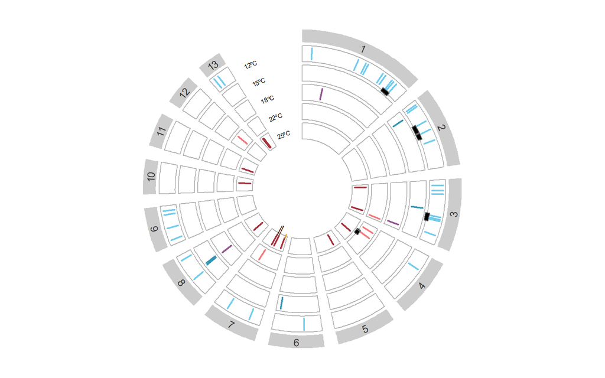

```r
#Step 3: add the 12C info

circos.track(ylim = c(0, 1), track.height = 0.1, bg.border = c(rep("grey70",13), "white"),
             panel.fun=function(region, value, ...) {
  chr=CELL_META$sector.index
  xlim=CELL_META$xlim
  ylim=CELL_META$ylim



  circos.lines(x= filter(temp, Condition == "12C" & CHR == chr)$BP,
               y = filter(temp, Condition == "12C" & CHR == chr)$height,
               type="h", col="#74CCED", lwd=2)})
circos.text(1, .5, "12ºC", facing = "bending.inside", sector.index = "0", cex = 0.5, adj = c(0.05, 0.5))

  pos=circlize(c(5121000, 5621000), c(-0.35, 0.0), sector.index = "1")
draw.sector(pos[1, "theta"], pos[2, "theta"], pos[1, "rou"], pos[2, "rou"],
    clock.wise = TRUE, col = "black", border="grey40")
  pos=circlize(c(1555000, 2055000), c(-0.35, 0.0), sector.index = "2")
draw.sector(pos[1, "theta"], pos[2, "theta"], pos[1, "rou"], pos[2, "rou"],
    clock.wise = TRUE, col = "black", border="grey40")
  pos=circlize(c(1178000, 1678000), c(-0.35, 0.0), sector.index = "2")
draw.sector(pos[1, "theta"], pos[2, "theta"], pos[1, "rou"], pos[2, "rou"],
    clock.wise = TRUE, col = "black", border="grey40")
  pos=circlize(c(1122000, 1622000), c(-0.35, 0.0), sector.index = "2")
draw.sector(pos[1, "theta"], pos[2, "theta"], pos[1, "rou"], pos[2, "rou"],
    clock.wise = TRUE, col = "black", border="grey40")
  pos=circlize(c(1925000, 2425000), c(-0.35, 0.0), sector.index = "3")
draw.sector(pos[1, "theta"], pos[2, "theta"], pos[1, "rou"], pos[2, "rou"],
    clock.wise = TRUE, col = "black", border="grey40")



#Step 4: add the 15C info
circos.track(ylim = c(0, 1), track.height = 0.1, bg.border=c(rep("grey70",13), "white"),
             panel.fun=function(region, value, ...) {
  chr=CELL_META$sector.index
  xlim=CELL_META$xlim
  ylim=CELL_META$ylim

  circos.lines(x= filter(temp, Condition == "15C" & CHR == chr)$BP,
               y = filter(temp, Condition == "15C" & CHR == chr)$height,
               type="h", col="#3596B5", lwd=2)})

circos.text(1, .5, "15ºC", facing = "bending.inside", sector.index = "0", cex = 0.5, adj = c(0.05, 0.5))


#Step 5: add the 18C info
circos.track(ylim = c(0, 1), track.height = 0.1, bg.border=c(rep("grey70",13), "white"),
             panel.fun=function(region, value, ...) {
  chr=CELL_META$sector.index
  xlim=CELL_META$xlim
  ylim=CELL_META$ylim

  circos.lines(x= filter(temp, Condition == "18C" & CHR == chr)$BP,
               y = filter(temp, Condition == "18C" & CHR == chr)$height,
               type="h", col="#955490", lwd=2)})

circos.text(1, .5, "18ºC", facing = "bending.inside", sector.index = "0", cex = 0.5, adj = c(0, 0.5))

#Step 6: add the 22C info
circos.track(ylim = c(0, 1), track.height = 0.1, bg.border = c(rep("grey70",13), "white"),
             panel.fun=function(region, value, ...) {
  chr=CELL_META$sector.index
  xlim=CELL_META$xlim
  ylim=CELL_META$ylim

  circos.lines(x= filter(temp, Condition == "22C" & CHR == chr)$BP,
               y = filter(temp, Condition == "22C" & CHR == chr)$height,
               type="h", col="#F4797D", lwd=2)})
circos.text(1, .5, "22ºC", facing = "bending.inside", sector.index = "0", cex = 0.5, adj = c(0.05, 0.5))

  pos=circlize(c(938000, 1438000), c(-0.35, 0.0), sector.index = "4")
draw.sector(pos[1, "theta"], pos[2, "theta"], pos[1, "rou"], pos[2, "rou"],
    clock.wise = TRUE, col = "black", border="grey40")
  pos=circlize(c(1062000, 1562000), c(-0.35, 0.0), sector.index = "4")
draw.sector(pos[1, "theta"], pos[2, "theta"], pos[1, "rou"], pos[2, "rou"],
    clock.wise = TRUE, col = "black", border="grey40")

#Step 7: add the 25C info
circos.track(ylim = c(0, 1), track.height = 0.1, bg.border = c(rep("grey70",13), "white"),
             panel.fun=function(region, value, ...) {
  chr=CELL_META$sector.index
  xlim=CELL_META$xlim
  ylim=CELL_META$ylim

  circos.lines(x= filter(temp, Condition == "25C" & CHR == chr)$BP,
               y = filter(temp, Condition == "25C" & CHR == chr)$height,
               type="h", col="#A5333E", lwd=2)})
circos.text(1, .5, "25ºC", facing = "bending.inside", sector.index = "0", cex = 0.5, adj = c(0.05, 0.5))

  #GEA markers

 # pos=circlize(c(1504299, 1514464), c(-0.9, 0.0), sector.index = "7")
#draw.sector(pos[1, "theta"], pos[2, "theta"], pos[1, "rou"], pos[2, "rou"],
 #   clock.wise = TRUE, col = "#5e2f0d", border="#5e2f0d")
  #pos=circlize(c(1207411, 1215216), c(-0.9, 0.0), sector.index = "7")
#draw.sector(pos[1, "theta"], pos[2, "theta"], pos[1, "rou"], pos[2, "rou"],
 #   clock.wise = TRUE, col = "#5e2f0d", border="#5e2f0d")

  pos=circlize(c(1504299, 1511144), c(-0.9, 0.0), sector.index = "7")
draw.sector(pos[1, "theta"], pos[2, "theta"], pos[1, "rou"], pos[2, "rou"],
    clock.wise = TRUE, col = "#5e2f0d", border="#5e2f0d")
  pos=circlize(c(1505695, 1513466), c(-0.9, 0.0), sector.index = "7")
draw.sector(pos[1, "theta"], pos[2, "theta"], pos[1, "rou"], pos[2, "rou"],
    clock.wise = TRUE, col = "#5e2f0d", border="#5e2f0d")
  pos=circlize(c(1507820, 1514464), c(-0.9, 0.0), sector.index = "7")
draw.sector(pos[1, "theta"], pos[2, "theta"], pos[1, "rou"], pos[2, "rou"],
    clock.wise = TRUE, col = "#5e2f0d", border="#5e2f0d")
  pos=circlize(c(1505695, 1513466), c(-0.9, 0.0), sector.index = "7")
draw.sector(pos[1, "theta"], pos[2, "theta"], pos[1, "rou"], pos[2, "rou"],
    clock.wise = TRUE, col = "#5e2f0d", border="#5e2f0d")
  pos=circlize(c(1507820, 1514464), c(-0.9, 0.0), sector.index = "7")
draw.sector(pos[1, "theta"], pos[2, "theta"], pos[1, "rou"], pos[2, "rou"],
    clock.wise = TRUE, col = "#5e2f0d", border="#5e2f0d")
  pos=circlize(c(1505695, 1513466), c(-0.9, 0.0), sector.index = "7")
draw.sector(pos[1, "theta"], pos[2, "theta"], pos[1, "rou"], pos[2, "rou"],
    clock.wise = TRUE, col = "#5e2f0d", border="#5e2f0d")
  pos=circlize(c(1507820, 1514464), c(-0.9, 0.0), sector.index = "7")
draw.sector(pos[1, "theta"], pos[2, "theta"], pos[1, "rou"], pos[2, "rou"],
    clock.wise = TRUE, col = "#5e2f0d", border="#5e2f0d")
  pos=circlize(c(1207411, 1214000), c(-0.9, 0.0), sector.index = "7")
draw.sector(pos[1, "theta"], pos[2, "theta"], pos[1, "rou"], pos[2, "rou"],
    clock.wise = TRUE, col = "#5e2f0d", border="#5e2f0d")
  pos=circlize(c(1208740, 1215216), c(-0.9, 0.0), sector.index = "7")
draw.sector(pos[1, "theta"], pos[2, "theta"], pos[1, "rou"], pos[2, "rou"],
    clock.wise = TRUE, col = "#5e2f0d", border="#5e2f0d")
  pos=circlize(c(95000, 183000), c(-0.35, 0.0), sector.index = "7")
draw.sector(pos[1, "theta"], pos[2, "theta"], pos[1, "rou"], pos[2, "rou"],
    clock.wise = TRUE, col = "#e2a529", border="#e2a529")
```

```r
#highlight.sector(c("f", "g"), col = NA, border = "green",
 #   lwd = 2, track.index = c(2, 3), padding = c(0.1, 0.1, 0.1, 0.1))
```

# 4 Number of predicted genes with SNPs with the highest predicted effect of the SNPs associated

The SNPeff (Cingolani et al. 2012) results were obtained by using the script snpeffbuildwithnewannotationandrun.sh that can be found in my Github page. For further information on the impact and effect categories can be found in the SNPeff website https://pcingola.github.io/SnpEff/snpeff/inputoutput/ where the authors describe the effect (sequence ontology) and the effect’s impact.

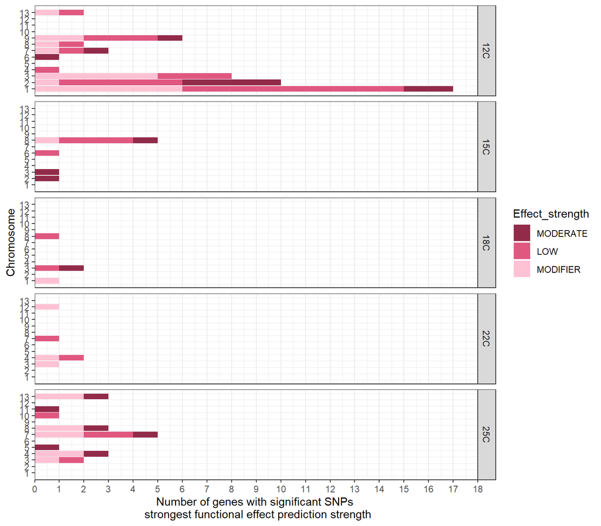

```r
pheno_table<-read_csv("all_varfin_temp.csv") %>% rename(Condition=cond, Phenotype=coliname)


annotall<-read_csv("annotationsgenefromnewgff3.csv") %>% rename(Gene=gene)

signif12c<-read_tsv("Significant_GEMMA_12C_temperatureswithphen_fdr0.1_v1.tsv", col_names = c("CHR", "BP", "Phenotype"))
signif15c<-read_tsv("Significant_GEMMA_15C_temperatureswithphen_fdr0.1_v1.tsv", col_names = c("CHR", "BP", "Phenotype"))
signif18c<-read_tsv("Significant_GEMMA_18C_temperatureswithphen_fdr0.1_v1.tsv", col_names = c("CHR", "BP", "Phenotype"))
signif22c<-read_tsv("Significant_GEMMA_22C_temperatureswithphen_fdr0.1_v1.tsv", col_names = c("CHR", "BP", "Phenotype"))
signif25c<-read_tsv("Significant_GEMMA_25C_temperatureswithphen_fdr0.1_v1.tsv", col_names = c("CHR", "BP", "Phenotype"))

significant<-full_join(signif12c, signif15c) %>% full_join(signif18c) %>% full_join(signif22c) %>% full_join(signif25c)



snpeffresultsnew080424<-read_csv("highesteffectlittle.csv", col_names = FALSE)
names(snpeffresultsnew080424) <- c("variant", "Variant_type", "Effect_strength", "Gene", "CHR", "BP")

snpeffresultsnew080424_1<- snpeffresultsnew080424 %>% left_join(annotall) %>% left_join(significant) %>% left_join(pheno_table)
write_csv(snpeffresultsnew080424_1, "forpubsnpeffresults.csv")

#unique(snpeffresultsnew080424_1$Gene)

snpeffresultsnew080424_16<-snpeffresultsnew080424_1 %>% dplyr::select( Gene, chromosome, start, end, Seq_Description) %>% drop_na(Seq_Description) %>% # remove NA values
  filter(!grepl('unnamed_protein_product', Seq_Description)) %>% # remove unnamed pred. genes
  filter(!grepl('uncharacterized_protein', Seq_Description)) %>% # remove unnamed pred. genes
  filter(!grepl('_predicted_protein', Seq_Description)) %>%
  filter(!grepl('SPQ18253.1_2af7a199-4405-43fb-abde-30e69e36a884', Seq_Description)) %>%
  filter(!grepl('hypothetical', Seq_Description))

#unique(snpeffresultsnew080424_16$Gene)

snpeffresultsnew080424_11<- snpeffresultsnew080424_1%>% ungroup() %>% dplyr::select(!(11:61)) %>% filter(Effect_strength =="MODERATE")
snpeffresultsnew080424_12<- snpeffresultsnew080424_1%>% ungroup() %>% dplyr::select(!(11:61)) %>% filter(Effect_strength =="MODIFIER")
snpeffresultsnew080424_13<- snpeffresultsnew080424_1%>% ungroup() %>% dplyr::select(!(11:61)) %>% filter(Effect_strength =="LOW")
snpeffresultsnew080424_14<- snpeffresultsnew080424_1%>% ungroup() %>% dplyr::select(!(11:61)) %>% filter(Seq_Description =="uncharacterized_protein_MYCGRDRAFT_89611")  %>% filter(Effect_strength =="MODIFIER")
snpeffresultsnew080424_15<- snpeffresultsnew080424_1%>% ungroup() %>% dplyr::select(!(11:61))
#%>% filter(Variant_type %in% c("5_prime_UTR_premature_start_codon_gain_variant", "5_prime_UTR_variant"))
write_csv(snpeffresultsnew080424_11, "forpubsnpeffresultsonlymoderate.csv")
signifsubnumbgenes<-snpeffresultsnew080424_1 %>% group_by(Condition, CHR, Variant_type, Effect_strength, Gene, Phenotype) %>% count()



signifsubnumbgenes_1<-snpeffresultsnew080424_1 %>% group_by(Condition, CHR, Variant_type, Effect_strength, Gene, Phenotype) %>% count() %>% dplyr::select(-n, -Variant_type, -Gene, -Phenotype) %>% ungroup() %>% group_by(Condition, Effect_strength, CHR) %>% count() %>% ungroup()

signifsubnumbgenes_1$Effect_strength <- factor(signifsubnumbgenes_1$Effect_strength, levels=c('MODERATE', 'LOW', 'MODIFIER'))

signifsubnumbgenes_1 %>% ggplot(aes(x=CHR , y=n, fill=Effect_strength))+geom_bar(position="stack", stat="identity") + facet_grid(rows=vars(Condition))+ coord_flip()+scale_x_continuous(breaks=seq(1,13, by=1) )+ labs(x="Chromosome", y="Number of genes with significant SNPs \n strongest functional effect prediction strength")+theme_bw() +
  theme(panel.grid.major.y = element_blank())+scale_y_continuous(limits=c(0,18),expand=c(0,0),breaks=seq(0,18, by=1) )+ scale_fill_manual(values = c("#922b4a","#e05780" , "#ffc2d4"))
```

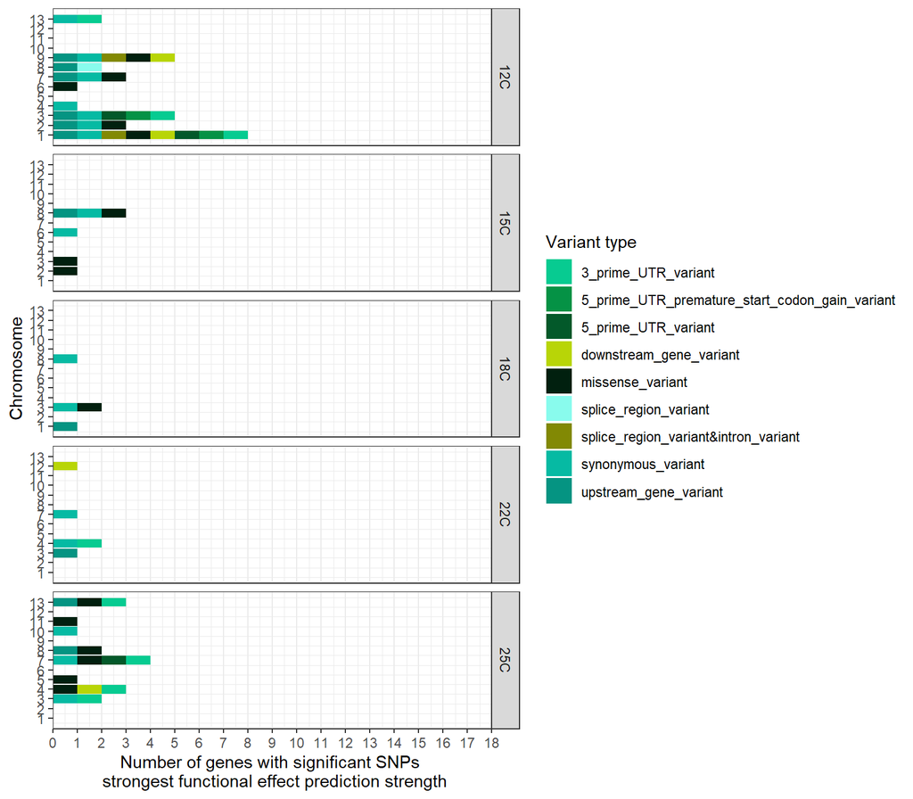

```r
signifsubnumbgenes_2<-snpeffresultsnew080424_1 %>% group_by(Condition, CHR, Variant_type, Effect_strength, Gene, Phenotype) %>% count() %>% ungroup()%>% dplyr::select(-n, -Gene, -Phenotype) %>% ungroup() %>% distinct()%>% group_by(Condition, Effect_strength, Variant_type, CHR) %>% count()

signifsubnumbgenes_2$Effect_type<-paste(signifsubnumbgenes_2$Variant_type, "_", signifsubnumbgenes_2$Effect_strength)

signifsubnumbgenes_2$Effect_type[signifsubnumbgenes_2$Effect_type == 'Orange St'] <- 'Portola Pkwy'

signifsubnumbgenes_2 %>% ggplot(aes(x=CHR , y=n, fill=Variant_type))+geom_bar(position="stack", stat="identity") + facet_grid(rows=vars(Condition))+ coord_flip()+scale_x_continuous(breaks=seq(1,13, by=1) )+ labs(x="Chromosome", y="Number of genes with significant SNPs \n strongest functional effect prediction strength")+theme_bw() +
  theme(panel.grid.major.y = element_blank())+scale_y_continuous(limits=c(0,18),expand=c(0,0),breaks=seq(0,18, by=1) )+ scale_fill_manual(values = c("#07cb91", "#059245", "#03592a", "#b8d507", "#01200F", "#89fbed", "#828904", "#06baa3", "#059482"), name="Variant type")
```

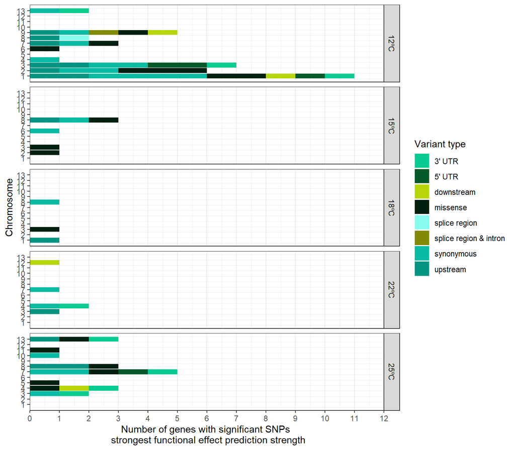

```r
suppltable3<-read_csv("Supplementary_Table_S3.csv")

lali<-suppltable3 %>% dplyr::select(-Phenotype) %>% dplyr::select(Condition, CHROM, Highest_variant_type, Gene, Highest_effect) %>% distinct()

lali2<-read_csv("lali2.csv")

conditionspretty<-c("12ºC", "15ºC", "18ºC", "22ºC", "25ºC")
names(conditionspretty) <- c("12C", "15C", "18C", "22C", "25C")
variantypy<-c("upstream", "synonymous", "5' UTR", "missense", "3' UTR", "downstream", "splice region", "splice region & intron")
names(variantypy) <- c(unique(lali2$Highest_variant_type))

lali2%>% group_by(Condition, CHROM, Highest_variant_type)%>% count() %>% ungroup() %>% ggplot(aes(x=CHROM , y=n, fill=Highest_variant_type))+geom_bar(position="stack", stat="identity") + facet_grid(rows=vars(Condition), labeller=labeller(Condition=conditionspretty))+ coord_flip()+scale_x_continuous(breaks=seq(1,13, by=1) )+ labs(x="Chromosome", y="Number of genes with significant SNPs \n strongest functional effect prediction strength")+theme_bw() +
  theme(panel.grid.major.y = element_blank())+scale_y_continuous(limits=c(0,12),expand=c(0,0),breaks=seq(0,12, by=1) )+ scale_fill_manual(values = c("#07cb91",  "#03592a", "#b8d507", "#01200F", "#89fbed", "#828904", "#06baa3", "#059482"), name="Variant type", labels=c(variantypy))
```

# References

Cingolani, Pablo, Adrian Platts, Le Lily Wang, Melissa Coon, Tung Nguyen, Luan Wang, Susan J. Land, Xiangyi Lu, and Douglas M. Ruden. 2012. “A Program for Annotating and Predicting the Effects of Single Nucleotide Polymorphisms, SnpEff: SNPs in the Genome of Drosophila Melanogaster Strain w <sup>1118</sup> ; Iso-2; Iso-3.” *Fly* 6 (2): 80–92. https://doi.org/10.4161/fly.19695.

Lendenmann, M H, D Croll, J Palma-Guerrero, E L Stewart, and B A McDonald. 2016. “QTL Mapping of Temperature Sensitivity Reveals Candidate Genes for Thermal Adaptation and Growth Morphology in the Plant Pathogenic Fungus Zymoseptoria Tritici.” *Heredity* 116 (4): 384–94. https://doi.org/10.1038/hdy.2015.111.